# **Traffic Patterns Based on Property in Maryland**

Member 1: Hafeez Mustafa, Contribution: 100% "We, all team members, agree together that the above information is true, and we are confident about our contributions to this submitted project/final tutorial."

Hafeez Mustafa 5/7/24

Hafeez Mustafa is a one man team and did the whole project 😀

# **Introduction:**

According to the [U.S. Bureau of Labor Statistics](https://www.bls.gov/news.release/cesan.nr0.htm), housing was the largest share of annual expenditures in 2022 at 33.3% alongside transportation the second largest share at 16.8%. This implies that both housing and transportation play a critical role in determining the costs faced by individual Americans households. However, while expenditures are important, time is also crucially important, and traffic is a massive time waster with [roughly 59 hours wasted per person each year in Baltimore alone.](https://www.wmar2news.com/local/study-reveals-how-much-gas-time-money-you-waste-stuck-in-traffic-each-year)

This project will attempt to mainly question traffic particularly if there is a relationship between the cost of residential areas in each area and the traffic-related metrics recorded. Also, some of he traffic-based differences in each area based on whether they are rural or urban will also be evaluated to better understand data differences in different settings. Then, a model will be constructed to show whether we can successfully predict traffic-related metrics in each area based on the housing costs near it.

Traffic will be analyzed by the following metrics:

1.) **AADT** (Annual Average Daily Traffic) is a traffic metric which measures the average number of vehicles going through a specific area over the course of a year.

2.) **K-Factor** which measures how much of daily traffic occurs at the peak hour of traffic. Is good for analyzing how bad the traffic is on average at peak times compared to the rest of the day.

Cost of residential areas will be caluclated with the following metrics:

1.) **Residential prices:** The average price of properties sold off in given area.

2.) **Appraised value:** The amound of money a property is estimated to be at by a real-estate agent or someone with expertise. This differs from its actual value which is the price the property is sold at.

# **Sources:**

The main source that will be utilized for this project is [MDOT SHA Annual Average Daily Traffic (AADT)](https://data-maryland.opendata.arcgis.com/datasets/mdot-sha-annual-average-daily-traffic-aadt-locations/explore?showTable=true) which is segmented by points which document the observed AADT at their respective road location. This source is the main dataset which contains the data that we want to predict for the machine learning section on whether residential prices nearby have a mathematical relationship with nearby traffic. Also, this source contains both AADT and K-Factor metrics and has an X-Y coordinate system that can be converted into a longitude-latitude metric.

The second source for the project is [2021 Total Sales by House Types by Zip Code](https://planning.maryland.gov/MSDC/Pages/sale_data/saledata.aspx) which contains information on residential sales in Maryland by zip code. This source exists to provide a more condensed dataset in comparison to the third dataset/source which has each individual housing unit and its price in Maryland listed. It will be used in the machine learning section and explanatory section to show the general trend between housing property values and traffic in each area.

The final source is [Maryland Property Data](https://data.imap.maryland.gov/datasets/042c633a05df48fa8561f245fccdd750_0/about) which is a large dataset (more than 2,000,000 rows) of properties in Maryland and their characteristics including owners, size, type, and monetary appraisal. This source will also have X-Y coordinates which will be converted to a latitude-longitude metric allowing it to be merged with the first dataset.

Furthermore, the first two sources have data related/based in 2021 hence allowing for the data to be analyzed in conjunction with each other. However, the third dataset has property values of 2022-2023 which is still close to 2021 but may add confounding variables to any data analysis/machine learning due to changes that could have occurred within two to three years. 2021 was chosen as the year for data analysis since it is the closest to current day and the effects of COVID-19 had begun to wear off that year (i.e. people went back to their jobs and traffic loads stabilized).

# **Data Cleaning:**

Cleaning the first two datasets.

Important Pre-Modification: The second dataset was already modified slightly by manually inputting the columns since they were formatted incorrectly in the csv file.

The first two datasets are read in as a csv file.

```python
import pandas as pd

# Importing and reading the two csv files as a dataframe using pandas
df1 = pd.read_csv("MDOT_SHA_Annual_Average_Daily_Traffic_-4877149214391780709(Source Number 1).csv")
df2 = pd.read_csv("Zip-Summy-Housing.csv")
```

Now dropping duplicate/NA values and obtaining important features that will be used in further sections for the first dataset.

```python
# No duplicates
print("No duplicates")
print(df1.shape)
print(df1.drop_duplicates().shape)
# No location errors
print("\nNo invalid locations")
print(df1['Location Error'].value_counts())
print("\n")
# Getting important features for first dataset
source1 = df1[['x', 'y', 'AADT 2021', 'Rural / Urban' , 'K-Factor']]
source1 = source1.dropna()
print("No missing values")
source1.shape
```

```
No duplicates
(8151, 60)
(8151, 60)

No invalid locations
Location Error
NO ERROR    8151
Name: count, dtype: int64


No missing values
```

```
(8151, 5)
```

Doing the same with the second dataset.

```python
# No duplicates
print("No duplicates")
print(df2.shape)
print(df2.drop_duplicates().shape)
# Selecting important features for the second dataset
df2.columns
source2 = df2[['Zipcode', 'Mean Total Value', 'Median Total Value']]
# No missing values
source2 = source2.dropna()
print("\nNo na values")
source2.shape
```

```
No duplicates
(487, 49)
(487, 49)

No na values
```

```
(487, 3)
```

Want to convert the Mean Total Value/Median Total Value to floats by removing the dollar sign and commas with regex and casting.

```python
source2 = source2.replace('[\$,]', '', regex=True).astype(int)
source2
```

|  | Zipcode | Mean Total Value | Median Total Value |
| --- | --- | --- | --- |
| 0 | 21502 | 141400 | 123000 |
| 1 | 21521 | 109875 | 87000 |
| 2 | 21530 | 238086 | 220000 |
| 3 | 21532 | 145634 | 125000 |
| 4 | 21539 | 102836 | 87555 |
| ... | ... | ... | ... |
| 482 | 21851 | 183905 | 185000 |
| 483 | 21862 | 999 | 999 |
| 484 | 21863 | 235335 | 225000 |
| 485 | 21864 | 999 | 999 |
| 486 | 21872 | 999 | 999 |

487 rows × 3 columns

Data Cleaning for source 3: Note, due to the size of the dataset additional precautions had to be made which are elaborated in the comments in the code below.

The main idea is to use this large dataset in the machine learning section rather than exploratory data analysis.

```python
# Used google drive is used since the third file is too large to import manually
from google.colab import drive
drive.mount('/content/drive')
# The columns are extracted befor as there is too much data which causes the program to crash when it runs out of RAM
df3 = pd.read_csv("/content/drive/MyDrive/Maryland_Property_Data_-_Parcel_Points.csv", usecols = ['X', 'Y', 'NFMTTLVL', 'DESCSTYL'])
df3.shape
```

```
(2358584, 4)
```

Now, we are dropping missing values and then finding the ten most popular property types/style which will be used to determine what will be included in the dataset.

```python
df3 = df3.dropna()
(df3['DESCSTYL'].value_counts()).head(10)
```

```
DESCSTYL
STRY 2 Story With Basement                       468682
STRY 1 Story With Basement                       250700
STRY Townhouse-Center Unit 2 Story With Basem    204955
HOUSING Condominium (residential)                181729
STRY 2 Story No Basement                         148660
STRY 1 Story No Basement                         145464
STRY Townhouse-End Unit 2 Story With Basement    118290
STRY 1.5 Story With Basement                     111029
STRY Split Foyer                                  93250
STRY 1.5 Story No Basement                        40921
Name: count, dtype: int64
```

Want to reduce this dataset to just story buildings with/without basements. This is because condos/townhouses/apartments tend to house many different households and their *appraised value* is inflated because of it. Since the dataset does not include how many people were housed at the time it is better to exclude such datapoints. Also, other buildings such as schools and hospitals are listed in the unmodified dataset which are clear outliers if they were included (thus removed).

```python
df3 = df3[(df3['DESCSTYL'] == 'STRY 2 Story With Basement') | (df3['DESCSTYL'] == 'STRY 1 Story With Basement') | (df3['DESCSTYL'] == 'STRY 2 Story No Basement')
| (df3['DESCSTYL'] == 'STRY 1 Story No Basement') | (df3['DESCSTYL'] == 'STRY 1.5 Story With Basement') | (df3['DESCSTYL'] == 'STRY 1.5 Story No Basement')  ]
df3.shape
```

```
(1165456, 4)
```

Finally remove any duplicates and check if the data is accurate (makes sense).

```python
df3 = df3.drop_duplicates()
# A mean of appraised value of 472,737 seems realistic.
df3.describe()
```

|  | X | Y | NFMTTLVL |
| --- | --- | --- | --- |
| count | 1.165450e+06 | 1.165450e+06 | 1.165450e+06 |
| mean | -8.548832e+06 | 4.737208e+06 | 4.727378e+05 |
| std | 6.940348e+04 | 5.352311e+04 | 4.021286e+05 |
| min | -8.848425e+06 | 4.570409e+06 | 2.100000e+03 |
| 25% | -8.576689e+06 | 4.711689e+06 | 2.803000e+05 |
| 50% | -8.548594e+06 | 4.741025e+06 | 4.063000e+05 |
| 75% | -8.517973e+06 | 4.777866e+06 | 5.754000e+05 |
| max | -8.354580e+06 | 4.825755e+06 | 1.900558e+08 |

# **Data Exploration:**

**Relationship Between the Two Traffic Metrics**

Now, we examine the correlation between AADT in 2021 and K-levels to better understand the relationship between the two traffic metrics. However, first we do some data cleaning by removing outliers.

```python
import matplotlib.pyplot as plt
import scipy.stats as stat

#test3 = df1[['AADT 2021', 'K-Factor', 'Rural / Urban']]
print(df1['K-Factor'].describe())
print(df1['AADT 2021'].describe())
# Removing outliers that are 2 standard deviations away, since there are outliers at least 5 standard deviations away from the mean for\
# both series
offset31 = 2 * df1['K-Factor'].std()
offset32 = 2 * df1['AADT 2021'].std()
test3 = df1[['AADT 2021', 'K-Factor', 'x', 'y']]
test3 = test3[(test3['K-Factor'] < offset31 + test3['K-Factor'].mean()) & (test3['K-Factor'] > test3['K-Factor'].mean() - offset31) ]
test3 = test3[(test3['AADT 2021'] < offset32 + test3['AADT 2021'].mean()) & \
 (test3['AADT 2021'] > test3['AADT 2021'].mean() - offset32) ]
```

```
count    8151.000000
mean        9.430201
std         2.122873
min         5.520000
25%         8.190000
50%         9.000000
75%        10.110000
max        42.020000
Name: K-Factor, dtype: float64
count      8151.000000
mean      11459.910808
std       23363.876137
min          25.000000
25%        2000.000000
50%        4720.000000
75%       10690.500000
max      232252.000000
Name: AADT 2021, dtype: float64
```

Now applying a correlation test we get the following

```python
test3.corr()
```

|  | AADT 2021 | K-Factor | x | y |
| --- | --- | --- | --- | --- |
| AADT 2021 | 1.000000 | -0.340754 | 0.027386 | -0.046475 |
| K-Factor | -0.340754 | 1.000000 | -0.053681 | 0.087178 |
| x | 0.027386 | -0.053681 | 1.000000 | -0.502872 |
| y | -0.046475 | 0.087178 | -0.502872 | 1.000000 |

This correlation graph and R value -0.34 from the correlation matrix above represents the overall weak negative linear relationship between AADT and K-Factor which implies that there is a trend whereas AADT decreases then the K-Factor increases. In other words, the share of a peak traffic hour comprises more of traffic on a given day on average for roads with less traffic compared to more. So, in high traffic areas the traffic tends to be dispersed more evenly throughout the day and based on the graph below it seems that around 5,000 AADT the K-Factor has a high variance between a K-Factor of 7 and 12. Note in the graph below, while there is a weak linear relationship, there seems to be a stronger non-linear quadratic relationship between the two factors. This might play a role in applying a polynomial kernel to K-Factor and residential prices for the next section assuming that AADT has a linear relationship with residential prices or in the next section appraised value (note this does not occur due to the results of the construction of machine learning models in the next section.)

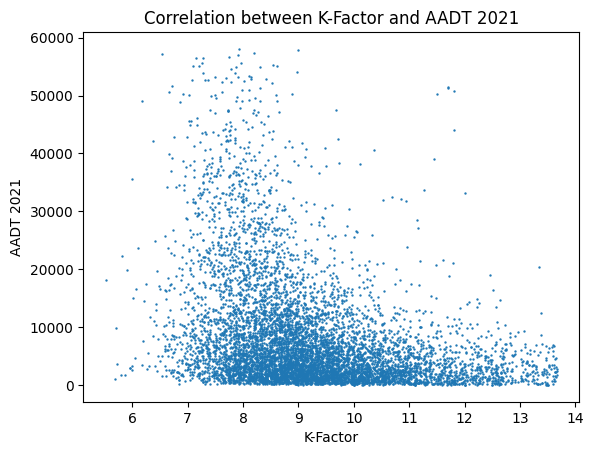

```python
test3.plot.scatter(x = 'K-Factor', y = 'AADT 2021', s = 0.5)
plt.title("Correlation between K-Factor and AADT 2021")
plt.show()
```

Now we want to distinguish between Rural and Urban Areas in order to better understand the impact of other features on the relationship between the two different traffic metrics.

```python
test1 = df1[['AADT 2021', 'K-Factor', 'Rural / Urban']]
# Removing outliers that are 2 standard deviations away
test1 = test1[test1['Rural / Urban'] == 'Rural']
offset31 = 2 * test1['K-Factor'].std()
offset32 = 2 * test1['AADT 2021'].std()
test1 = test1[['AADT 2021', 'K-Factor']]
test1 = test1[(test1['K-Factor'] < offset31 + test1['K-Factor'].mean()) & (test1['K-Factor'] > test1['K-Factor'].mean() - offset31) ]
test1 = test1[(test1['AADT 2021'] < offset32 + test1['AADT 2021'].mean()) & \
(test1['AADT 2021'] > test1['AADT 2021'].mean() - offset32) ]

test2 = df1[['AADT 2021', 'K-Factor', 'Rural / Urban']]
# Removing outliers that are 2 standard deviations away
test2 = test2[test2['Rural / Urban'] == 'Urban']
offset31 = 2 * test2['K-Factor'].std()
offset32 = 2 * test2['AADT 2021'].std()
test2 = df1[['AADT 2021', 'K-Factor']]
test2 = test2[(test2['K-Factor'] < offset31 + test2['K-Factor'].mean()) & (test2['K-Factor'] > test2['K-Factor'].mean() - offset31) ]
test2 = test2[(test2['AADT 2021'] < offset32 + test2['AADT 2021'].mean()) & \
(test2['AADT 2021'] > test2['AADT 2021'].mean() - offset32) ]
```

The correlation of K-Factor and AADT with Rural and Urban areas respectively. The results of splitting them into Rural and Urban demonstrate that they are roughly the same in respective to the weak negative linear relationship between AADT and K-Factor.

```python
print("This is the correlation for rural areas.")
print(test1.corr())
print("\n")
print("This is the correlation for urban areas.")
print(test2.corr())
```

```
This is the correlation for rural areas.
           AADT 2021  K-Factor
AADT 2021   1.000000 -0.228711
K-Factor   -0.228711  1.000000


This is the correlation for urban areas.
           AADT 2021  K-Factor
AADT 2021   1.000000 -0.342982
K-Factor   -0.342982  1.000000
```

From the results above and the graph below it is safe to **conclude that the correlative differences in trend between rural and urban areas is quite small** hence the confounding variable "Urban/Rural" are negligible to the relationship between the two traffic metrics even if rural areas practically have distinct spatial and structural differences such as the types of roads found in each (i.e. more interstates in urban areas). Furthermore, since the relationship is linearly weak and linear regression will be utilized in the machine learning section it seems optimal to use polynomial kernel to transform the K-Factor data.

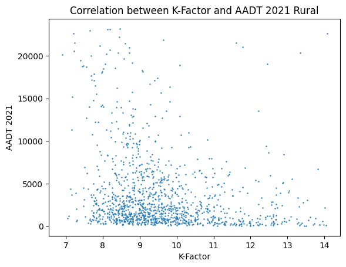

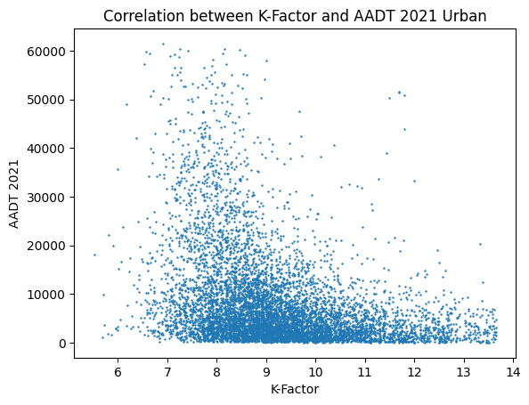

```python
test1.plot.scatter(x = 'K-Factor', y = 'AADT 2021', s = 0.5)
plt.title("Correlation between K-Factor and AADT 2021 Rural")
plt.show()

test2.plot.scatter(x = 'K-Factor', y = 'AADT 2021', s = 0.5)
plt.title("Correlation between K-Factor and AADT 2021 Urban")
plt.show()
```

Now that we have analyzed the relationship between the two traffic metrics we want to further analyze the differences between urban and rural areas based on the percentage of cars contributing to AADT.

**Two-Sample T-Test** involving the ratio of AADT contribution by cars in Rural vs Urban areas.

Null hypothesis: The ratio between the Annual Average Daily Traffic (AADT) of cars over the total AADT in 2021 is the same for areas which are urban and rural in Maryland.